# Risk Factor Analysis

## Outcome Variable

**Outcome Variable:** stunted

## Predictor Variables

**Intervention Variable:** tr

**Adjustment Set:**

unadjusted

## Stratifying Variables

The analysis was stratified on these variable(s):

- single
- agecat
- studyid
- country

## Data Summary

| single | agecat | studyid | country | tr | stunted | n_cell | n |
| --- | --- | --- | --- | --- | --- | --- | --- |
| 0 | 6 months | ki1066203-TanzaniaChild2 | TANZANIA, UNITED REPUBLIC OF | Control | 0 | 342 | 1543 |
| 0 | 6 months | ki1066203-TanzaniaChild2 | TANZANIA, UNITED REPUBLIC OF | Control | 1 | 39 | 1543 |
| 0 | 6 months | ki1066203-TanzaniaChild2 | TANZANIA, UNITED REPUBLIC OF | Other | 0 | 340 | 1543 |
| 0 | 6 months | ki1066203-TanzaniaChild2 | TANZANIA, UNITED REPUBLIC OF | Other | 1 | 45 | 1543 |
| 0 | 6 months | ki1066203-TanzaniaChild2 | TANZANIA, UNITED REPUBLIC OF | Zinc | 0 | 690 | 1543 |
| 0 | 6 months | ki1066203-TanzaniaChild2 | TANZANIA, UNITED REPUBLIC OF | Zinc | 1 | 87 | 1543 |
| 1 | 6 months | ki1066203-TanzaniaChild2 | TANZANIA, UNITED REPUBLIC OF | Control | 0 | 33 | 151 |
| 1 | 6 months | ki1066203-TanzaniaChild2 | TANZANIA, UNITED REPUBLIC OF | Control | 1 | 8 | 151 |
| 1 | 6 months | ki1066203-TanzaniaChild2 | TANZANIA, UNITED REPUBLIC OF | Other | 0 | 36 | 151 |
| 1 | 6 months | ki1066203-TanzaniaChild2 | TANZANIA, UNITED REPUBLIC OF | Other | 1 | 0 | 151 |
| 1 | 6 months | ki1066203-TanzaniaChild2 | TANZANIA, UNITED REPUBLIC OF | Zinc | 0 | 68 | 151 |
| 1 | 6 months | ki1066203-TanzaniaChild2 | TANZANIA, UNITED REPUBLIC OF | Zinc | 1 | 6 | 151 |
| 0 | 24 months | ki1066203-TanzaniaChild2 | TANZANIA, UNITED REPUBLIC OF | Control | 0 | 1 | 4 |
| 0 | 24 months | ki1066203-TanzaniaChild2 | TANZANIA, UNITED REPUBLIC OF | Control | 1 | 0 | 4 |
| 0 | 24 months | ki1066203-TanzaniaChild2 | TANZANIA, UNITED REPUBLIC OF | Other | 0 | 2 | 4 |
| 0 | 24 months | ki1066203-TanzaniaChild2 | TANZANIA, UNITED REPUBLIC OF | Other | 1 | 0 | 4 |
| 0 | 24 months | ki1066203-TanzaniaChild2 | TANZANIA, UNITED REPUBLIC OF | Zinc | 0 | 0 | 4 |
| 0 | 24 months | ki1066203-TanzaniaChild2 | TANZANIA, UNITED REPUBLIC OF | Zinc | 1 | 1 | 4 |
| 0 | 6 months | ki1112895-Guatemala BSC | GUATEMALA | Control | 0 | 61 | 186 |
| 0 | 6 months | ki1112895-Guatemala BSC | GUATEMALA | Control | 1 | 30 | 186 |
| 0 | 6 months | ki1112895-Guatemala BSC | GUATEMALA | Other | 0 | 70 | 186 |
| 0 | 6 months | ki1112895-Guatemala BSC | GUATEMALA | Other | 1 | 25 | 186 |
| 1 | 6 months | ki1112895-Guatemala BSC | GUATEMALA | Control | 0 | 8 | 26 |
| 1 | 6 months | ki1112895-Guatemala BSC | GUATEMALA | Control | 1 | 4 | 26 |
| 1 | 6 months | ki1112895-Guatemala BSC | GUATEMALA | Other | 0 | 8 | 26 |
| 1 | 6 months | ki1112895-Guatemala BSC | GUATEMALA | Other | 1 | 6 | 26 |
| 0 | Birth | ki1119695-PROBIT | BELARUS | Control | 0 | 6519 | 13343 |
| 0 | Birth | ki1119695-PROBIT | BELARUS | Control | 1 | 21 | 13343 |
| 0 | Birth | ki1119695-PROBIT | BELARUS | Maternal | 0 | 6793 | 13343 |
| 0 | Birth | ki1119695-PROBIT | BELARUS | Maternal | 1 | 10 | 13343 |

[output cut: 116 more lines]

The following strata were considered:

- single: 0, agecat: 24 months, studyid: iLiNS_DYADM_LNS, country: MALAWI
- single: 0, agecat: 24 months, studyid: ki1066203-TanzaniaChild2, country: TANZANIA, UNITED REPUBLIC OF
- single: 0, agecat: 24 months, studyid: ki1119695-PROBIT, country: BELARUS
- single: 0, agecat: 24 months, studyid: ki1126311-ZVITAMBO, country: ZIMBABWE
- single: 0, agecat: 24 months, studyid: ki1135781-COHORTS, country: GUATEMALA
- single: 0, agecat: 24 months, studyid: ki1148112-iLiNS-DOSE, country: MALAWI
- single: 0, agecat: 24 months, studyid: ki1148112-iLiNS-DYAD-M, country: MALAWI
- single: 0, agecat: 6 months, studyid: iLiNS_DYADM_LNS, country: MALAWI
- single: 0, agecat: 6 months, studyid: ki1066203-TanzaniaChild2, country: TANZANIA, UNITED REPUBLIC OF
- single: 0, agecat: 6 months, studyid: ki1112895-Guatemala BSC, country: GUATEMALA
- single: 0, agecat: 6 months, studyid: ki1119695-PROBIT, country: BELARUS
- single: 0, agecat: 6 months, studyid: ki1126311-ZVITAMBO, country: ZIMBABWE
- single: 0, agecat: 6 months, studyid: ki1135781-COHORTS, country: GUATEMALA
- single: 0, agecat: 6 months, studyid: ki1148112-iLiNS-DOSE, country: MALAWI
- single: 0, agecat: 6 months, studyid: ki1148112-iLiNS-DYAD-M, country: MALAWI
- single: 0, agecat: Birth, studyid: iLiNS_DYADM_LNS, country: MALAWI
- single: 0, agecat: Birth, studyid: ki1119695-PROBIT, country: BELARUS
- single: 0, agecat: Birth, studyid: ki1126311-ZVITAMBO, country: ZIMBABWE
- single: 0, agecat: Birth, studyid: ki1135781-COHORTS, country: GUATEMALA
- single: 0, agecat: Birth, studyid: ki1148112-iLiNS-DYAD-M, country: MALAWI
- single: 1, agecat: 24 months, studyid: iLiNS_DYADM_LNS, country: MALAWI
- single: 1, agecat: 24 months, studyid: ki1119695-PROBIT, country: BELARUS
- single: 1, agecat: 24 months, studyid: ki1126311-ZVITAMBO, country: ZIMBABWE
- single: 1, agecat: 24 months, studyid: ki1135781-COHORTS, country: GUATEMALA
- single: 1, agecat: 24 months, studyid: ki1148112-iLiNS-DOSE, country: MALAWI
- single: 1, agecat: 24 months, studyid: ki1148112-iLiNS-DYAD-M, country: MALAWI
- single: 1, agecat: 6 months, studyid: iLiNS_DYADM_LNS, country: MALAWI
- single: 1, agecat: 6 months, studyid: ki1066203-TanzaniaChild2, country: TANZANIA, UNITED REPUBLIC OF
- single: 1, agecat: 6 months, studyid: ki1112895-Guatemala BSC, country: GUATEMALA
- single: 1, agecat: 6 months, studyid: ki1119695-PROBIT, country: BELARUS
- single: 1, agecat: 6 months, studyid: ki1126311-ZVITAMBO, country: ZIMBABWE
- single: 1, agecat: 6 months, studyid: ki1135781-COHORTS, country: GUATEMALA
- single: 1, agecat: 6 months, studyid: ki1148112-iLiNS-DOSE, country: MALAWI
- single: 1, agecat: 6 months, studyid: ki1148112-iLiNS-DYAD-M, country: MALAWI
- single: 1, agecat: Birth, studyid: ki1119695-PROBIT, country: BELARUS
- single: 1, agecat: Birth, studyid: ki1126311-ZVITAMBO, country: ZIMBABWE
- single: 1, agecat: Birth, studyid: ki1135781-COHORTS, country: GUATEMALA

### Dropped Strata

Some strata were dropped due to rare outcomes:

- single: 1, agecat: 6 months, studyid: ki1066203-TanzaniaChild2, country: TANZANIA, UNITED REPUBLIC OF
- single: 0, agecat: 24 months, studyid: ki1066203-TanzaniaChild2, country: TANZANIA, UNITED REPUBLIC OF
- single: 1, agecat: 6 months, studyid: ki1112895-Guatemala BSC, country: GUATEMALA
- single: 1, agecat: Birth, studyid: ki1119695-PROBIT, country: BELARUS
- single: 1, agecat: 24 months, studyid: ki1119695-PROBIT, country: BELARUS
- single: 0, agecat: 24 months, studyid: ki1126311-ZVITAMBO, country: ZIMBABWE
- single: 1, agecat: 24 months, studyid: ki1126311-ZVITAMBO, country: ZIMBABWE
- single: 1, agecat: Birth, studyid: ki1135781-COHORTS, country: GUATEMALA
- single: 1, agecat: 24 months, studyid: ki1135781-COHORTS, country: GUATEMALA
- single: 0, agecat: Birth, studyid: ki1148112-iLiNS-DYAD-M, country: MALAWI
- single: 1, agecat: 24 months, studyid: ki1148112-iLiNS-DYAD-M, country: MALAWI
- single: 0, agecat: 24 months, studyid: ki1148112-iLiNS-DYAD-M, country: MALAWI
- single: 0, agecat: Birth, studyid: iLiNS_DYADM_LNS, country: MALAWI
- single: 1, agecat: 24 months, studyid: iLiNS_DYADM_LNS, country: MALAWI
- single: 0, agecat: 24 months, studyid: iLiNS_DYADM_LNS, country: MALAWI

## Methods Detail

We’re interested in the causal parameters $E[Y_a]$ for all values of $a \in \mathcal{A}$. These parameters represent the mean outcome if, possibly contrary to fact, we intervened to set all units to have $A=a$. Under the randomization and positivity assumptions, these are identified by the statistical parameters $\psi_a=E_W[E_{Y|A,W}(Y|A=a,W)]$. In addition, we’re interested in the mean of $Y$, $E[Y]$ under no intervention (the observed mean). We will estimate these parameters by using SuperLearner to fit the relevant likelihood factors – $E_{Y|A,W}(Y|A=a,W)$ and $p(A=a|W)$, and then updating our likelihood fit using a joint TMLE.

For unadjusted analyses ($W=\{\}$), initial likelihoods were estimated using Lrnr_glm to estimate the simple $E(Y|A)$ and Lrnr_mean to estimate $p(A)$. For adjusted analyses, a small library containing Lrnr_glmnet, Lrnr_xgboost, and Lrnr_mean was used.

Having estimated these parameters, we will then use the delta method to estimate relative risks and attributable risks relative to a prespecified baseline level of $A$.

# Results Detail

## Results Plots

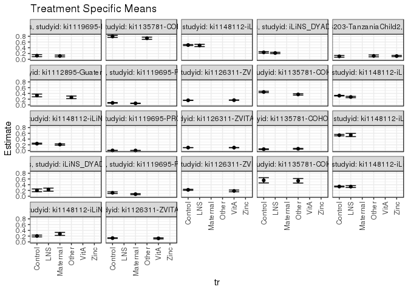

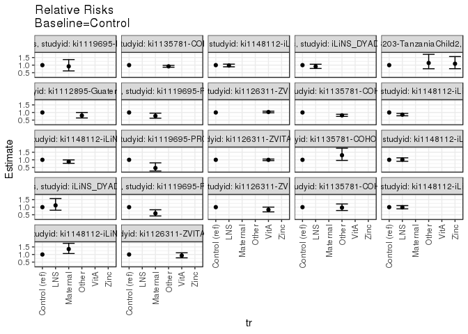

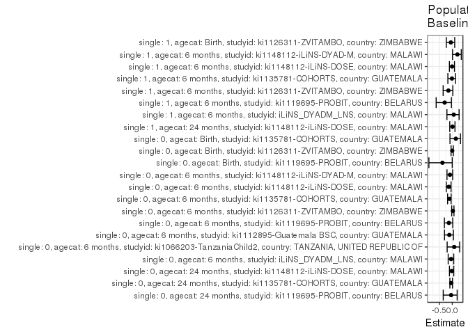

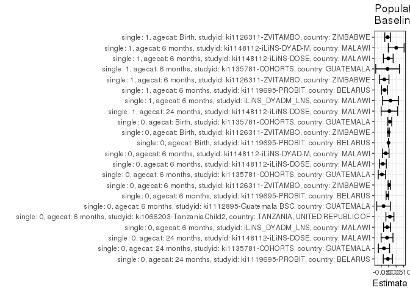

## Results Table

### Parameter: TSM

| single | agecat | studyid | country | intervention_level | baseline_level | estimate | ci_lower | ci_upper |
| --- | --- | --- | --- | --- | --- | --- | --- | --- |
| 0 | Birth | ki1119695-PROBIT | BELARUS | Control | NA | 0.0032110 | 0.0020125 | 0.0044095 |
| 0 | Birth | ki1119695-PROBIT | BELARUS | Maternal | NA | 0.0014699 | 0.0008620 | 0.0020779 |
| 0 | Birth | ki1126311-ZVITAMBO | ZIMBABWE | Control | NA | 0.1025163 | 0.0999019 | 0.1051307 |
| 0 | Birth | ki1126311-ZVITAMBO | ZIMBABWE | VitA | NA | 0.1022410 | 0.0977120 | 0.1067701 |
| 0 | Birth | ki1135781-COHORTS | GUATEMALA | Control | NA | 0.0479042 | 0.0372573 | 0.0585511 |
| 0 | Birth | ki1135781-COHORTS | GUATEMALA | Other | NA | 0.0623377 | 0.0493972 | 0.0752781 |
| 0 | 6 months | iLiNS_DYADM_LNS | MALAWI | Control | NA | 0.2397260 | 0.2140790 | 0.2653731 |
| 0 | 6 months | iLiNS_DYADM_LNS | MALAWI | LNS | NA | 0.2180451 | 0.1943691 | 0.2417211 |
| 0 | 6 months | ki1066203-TanzaniaChild2 | TANZANIA, UNITED REPUBLIC OF | Control | NA | 0.1023622 | 0.0719150 | 0.1328094 |
| 0 | 6 months | ki1066203-TanzaniaChild2 | TANZANIA, UNITED REPUBLIC OF | Other | NA | 0.1168831 | 0.0847803 | 0.1489860 |
| 0 | 6 months | ki1066203-TanzaniaChild2 | TANZANIA, UNITED REPUBLIC OF | Zinc | NA | 0.1119691 | 0.0897901 | 0.1341481 |
| 0 | 6 months | ki1112895-Guatemala BSC | GUATEMALA | Control | NA | 0.3296703 | 0.2822886 | 0.3770520 |
| 0 | 6 months | ki1112895-Guatemala BSC | GUATEMALA | Other | NA | 0.2631579 | 0.2178094 | 0.3085064 |
| 0 | 6 months | ki1119695-PROBIT | BELARUS | Control | NA | 0.0707719 | 0.0595232 | 0.0820207 |
| 0 | 6 months | ki1119695-PROBIT | BELARUS | Maternal | NA | 0.0545171 | 0.0465254 | 0.0625089 |
| 0 | 6 months | ki1126311-ZVITAMBO | ZIMBABWE | Control | NA | 0.1604664 | 0.1562777 | 0.1646551 |
| 0 | 6 months | ki1126311-ZVITAMBO | ZIMBABWE | VitA | NA | 0.1654519 | 0.1580494 | 0.1728544 |
| 0 | 6 months | ki1135781-COHORTS | GUATEMALA | Control | NA | 0.4497354 | 0.4259655 | 0.4735054 |
| 0 | 6 months | ki1135781-COHORTS | GUATEMALA | Other | NA | 0.3642857 | 0.3400479 | 0.3885236 |
| 0 | 6 months | ki1148112-iLiNS-DOSE | MALAWI | Control | NA | 0.3216080 | 0.3108594 | 0.3323567 |
| 0 | 6 months | ki1148112-iLiNS-DOSE | MALAWI | LNS | NA | 0.2751745 | 0.2521019 | 0.2982470 |
| 0 | 6 months | ki1148112-iLiNS-DYAD-M | MALAWI | Control | NA | 0.2397260 | 0.2226126 | 0.2568394 |
| 0 | 6 months | ki1148112-iLiNS-DYAD-M | MALAWI | Maternal | NA | 0.2095588 | 0.1872904 | 0.2318272 |
| 0 | 24 months | ki1119695-PROBIT | BELARUS | Control | NA | 0.1246537 | 0.0889570 | 0.1603504 |
| 0 | 24 months | ki1119695-PROBIT | BELARUS | Maternal | NA | 0.1147903 | 0.0840629 | 0.1455177 |
| 0 | 24 months | ki1135781-COHORTS | GUATEMALA | Control | NA | 0.7941176 | 0.7598242 | 0.8284111 |
| 0 | 24 months | ki1135781-COHORTS | GUATEMALA | Other | NA | 0.7313433 | 0.6940267 | 0.7686599 |
| 0 | 24 months | ki1148112-iLiNS-DOSE | MALAWI | Control | NA | 0.4941176 | 0.4764206 | 0.5118147 |
| 0 | 24 months | ki1148112-iLiNS-DOSE | MALAWI | LNS | NA | 0.4812207 | 0.4416274 | 0.5208139 |
| 1 | Birth | ki1126311-ZVITAMBO | ZIMBABWE | Control | NA | 0.1298077 | 0.1188815 | 0.1407339 |
| 1 | Birth | ki1126311-ZVITAMBO | ZIMBABWE | VitA | NA | 0.1208459 | 0.1019418 | 0.1397500 |
| 1 | 6 months | iLiNS_DYADM_LNS | MALAWI | Control | NA | 0.2033898 | 0.1547160 | 0.2520637 |
| 1 | 6 months | iLiNS_DYADM_LNS | MALAWI | LNS | NA | 0.2272727 | 0.1736757 | 0.2808698 |
| 1 | 6 months | ki1119695-PROBIT | BELARUS | Control | NA | 0.1196911 | 0.0904135 | 0.1489687 |
| 1 | 6 months | ki1119695-PROBIT | BELARUS | Maternal | NA | 0.0705521 | 0.0539114 | 0.0871929 |
| 1 | 6 months | ki1126311-ZVITAMBO | ZIMBABWE | Control | NA | 0.2211538 | 0.2030218 | 0.2392859 |
| 1 | 6 months | ki1126311-ZVITAMBO | ZIMBABWE | VitA | NA | 0.1836158 | 0.1524082 | 0.2148235 |
| 1 | 6 months | ki1135781-COHORTS | GUATEMALA | Control | NA | 0.5526316 | 0.4609121 | 0.6443511 |
| 1 | 6 months | ki1135781-COHORTS | GUATEMALA | Other | NA | 0.5357143 | 0.4567451 | 0.6146835 |
| 1 | 6 months | ki1148112-iLiNS-DOSE | MALAWI | Control | NA | 0.3363636 | 0.3219433 | 0.3507840 |
| 1 | 6 months | ki1148112-iLiNS-DOSE | MALAWI | LNS | NA | 0.3333333 | 0.3007539 | 0.3659128 |
| 1 | 6 months | ki1148112-iLiNS-DYAD-M | MALAWI | Control | NA | 0.2033898 | 0.1719100 | 0.2348697 |
| 1 | 6 months | ki1148112-iLiNS-DYAD-M | MALAWI | Maternal | NA | 0.2761194 | 0.2234264 | 0.3288124 |
| 1 | 24 months | ki1148112-iLiNS-DOSE | MALAWI | Control | NA | 0.5348837 | 0.5104627 | 0.5593048 |
| 1 | 24 months | ki1148112-iLiNS-DOSE | MALAWI | LNS | NA | 0.5409091 | 0.4857214 | 0.5960968 |

### Parameter: E(Y)

| single | agecat | studyid | country | intervention_level | baseline_level | estimate | ci_lower | ci_upper |
| --- | --- | --- | --- | --- | --- | --- | --- | --- |
| 0 | Birth | ki1119695-PROBIT | BELARUS | NA | NA | 0.0023233 | 0.0009399 | 0.0037067 |
| 0 | Birth | ki1126311-ZVITAMBO | ZIMBABWE | NA | NA | 0.1023097 | 0.0970802 | 0.1075392 |
| 0 | Birth | ki1135781-COHORTS | GUATEMALA | NA | NA | 0.0556328 | 0.0388671 | 0.0723985 |
| 0 | 6 months | iLiNS_DYADM_LNS | MALAWI | NA | NA | 0.2293907 | 0.1944746 | 0.2643068 |
| 0 | 6 months | ki1066203-TanzaniaChild2 | TANZANIA, UNITED REPUBLIC OF | NA | NA | 0.1108231 | 0.0951550 | 0.1264911 |
| 0 | 6 months | ki1112895-Guatemala BSC | GUATEMALA | NA | NA | 0.2956989 | 0.2299382 | 0.3614596 |
| 0 | 6 months | ki1119695-PROBIT | BELARUS | NA | NA | 0.0625225 | 0.0479052 | 0.0771397 |
| 0 | 6 months | ki1126311-ZVITAMBO | ZIMBABWE | NA | NA | 0.1642201 | 0.1557145 | 0.1727256 |
| 0 | 6 months | ki1135781-COHORTS | GUATEMALA | NA | NA | 0.4047619 | 0.3706847 | 0.4388391 |
| 0 | 6 months | ki1148112-iLiNS-DOSE | MALAWI | NA | NA | 0.2828619 | 0.2573898 | 0.3083340 |
| 0 | 6 months | ki1148112-iLiNS-DYAD-M | MALAWI | NA | NA | 0.2200957 | 0.1919941 | 0.2481973 |
| 0 | 24 months | ki1119695-PROBIT | BELARUS | NA | NA | 0.1191646 | 0.0724281 | 0.1659011 |
| 0 | 24 months | ki1135781-COHORTS | GUATEMALA | NA | NA | 0.7629630 | 0.7121433 | 0.8137826 |
| 0 | 24 months | ki1148112-iLiNS-DOSE | MALAWI | NA | NA | 0.4833659 | 0.4399956 | 0.5267363 |
| 1 | Birth | ki1126311-ZVITAMBO | ZIMBABWE | NA | NA | 0.1229885 | 0.1011525 | 0.1448245 |
| 1 | 6 months | iLiNS_DYADM_LNS | MALAWI | NA | NA | 0.2160000 | 0.1435694 | 0.2884306 |
| 1 | 6 months | ki1119695-PROBIT | BELARUS | NA | NA | 0.0923077 | 0.0566778 | 0.1279376 |
| 1 | 6 months | ki1126311-ZVITAMBO | ZIMBABWE | NA | NA | 0.1921397 | 0.1560182 | 0.2282613 |
| 1 | 6 months | ki1135781-COHORTS | GUATEMALA | NA | NA | 0.5454545 | 0.4244061 | 0.6665030 |
| 1 | 6 months | ki1148112-iLiNS-DOSE | MALAWI | NA | NA | 0.3338279 | 0.2981996 | 0.3694562 |
| 1 | 6 months | ki1148112-iLiNS-DYAD-M | MALAWI | NA | NA | 0.2538860 | 0.1923231 | 0.3154490 |
| 1 | 24 months | ki1148112-iLiNS-DOSE | MALAWI | NA | NA | 0.5399240 | 0.4795738 | 0.6002741 |

### Parameter: RR

| single | agecat | studyid | country | intervention_level | baseline_level | estimate | ci_lower | ci_upper |
| --- | --- | --- | --- | --- | --- | --- | --- | --- |
| 0 | Birth | ki1119695-PROBIT | BELARUS | Control | Control | 1.0000000 | 1.0000000 | 1.0000000 |
| 0 | Birth | ki1119695-PROBIT | BELARUS | Maternal | Control | 0.4577812 | 0.2620344 | 0.7997563 |
| 0 | Birth | ki1126311-ZVITAMBO | ZIMBABWE | Control | Control | 1.0000000 | 1.0000000 | 1.0000000 |
| 0 | Birth | ki1126311-ZVITAMBO | ZIMBABWE | VitA | Control | 0.9973149 | 0.9476188 | 1.0496171 |
| 0 | Birth | ki1135781-COHORTS | GUATEMALA | Control | Control | 1.0000000 | 1.0000000 | 1.0000000 |
| 0 | Birth | ki1135781-COHORTS | GUATEMALA | Other | Control | 1.3012987 | 0.9600624 | 1.7638210 |
| 0 | 6 months | iLiNS_DYADM_LNS | MALAWI | Control | Control | 1.0000000 | 1.0000000 | 1.0000000 |
| 0 | 6 months | iLiNS_DYADM_LNS | MALAWI | LNS | Control | 0.9095596 | 0.7809623 | 1.0593325 |
| 0 | 6 months | ki1066203-TanzaniaChild2 | TANZANIA, UNITED REPUBLIC OF | Control | Control | 1.0000000 | 1.0000000 | 1.0000000 |
| 0 | 6 months | ki1066203-TanzaniaChild2 | TANZANIA, UNITED REPUBLIC OF | Other | Control | 1.1418581 | 0.7617005 | 1.7117488 |
| 0 | 6 months | ki1066203-TanzaniaChild2 | TANZANIA, UNITED REPUBLIC OF | Zinc | Control | 1.0938521 | 0.7651681 | 1.5637248 |
| 0 | 6 months | ki1112895-Guatemala BSC | GUATEMALA | Control | Control | 1.0000000 | 1.0000000 | 1.0000000 |
| 0 | 6 months | ki1112895-Guatemala BSC | GUATEMALA | Other | Control | 0.7982456 | 0.6377988 | 0.9990549 |
| 0 | 6 months | ki1119695-PROBIT | BELARUS | Control | Control | 1.0000000 | 1.0000000 | 1.0000000 |
| 0 | 6 months | ki1119695-PROBIT | BELARUS | Maternal | Control | 0.7703215 | 0.6213560 | 0.9550003 |
| 0 | 6 months | ki1126311-ZVITAMBO | ZIMBABWE | Control | Control | 1.0000000 | 1.0000000 | 1.0000000 |
| 0 | 6 months | ki1126311-ZVITAMBO | ZIMBABWE | VitA | Control | 1.0310687 | 0.9790200 | 1.0858846 |
| 0 | 6 months | ki1135781-COHORTS | GUATEMALA | Control | Control | 1.0000000 | 1.0000000 | 1.0000000 |
| 0 | 6 months | ki1135781-COHORTS | GUATEMALA | Other | Control | 0.8100000 | 0.7440151 | 0.8818369 |
| 0 | 6 months | ki1148112-iLiNS-DOSE | MALAWI | Control | Control | 1.0000000 | 1.0000000 | 1.0000000 |
| 0 | 6 months | ki1148112-iLiNS-DOSE | MALAWI | LNS | Control | 0.8556206 | 0.7817731 | 0.9364439 |
| 0 | 6 months | ki1148112-iLiNS-DYAD-M | MALAWI | Control | Control | 1.0000000 | 1.0000000 | 1.0000000 |
| 0 | 6 months | ki1148112-iLiNS-DYAD-M | MALAWI | Maternal | Control | 0.8741597 | 0.7691203 | 0.9935444 |
| 0 | 24 months | ki1119695-PROBIT | BELARUS | Control | Control | 1.0000000 | 1.0000000 | 1.0000000 |
| 0 | 24 months | ki1119695-PROBIT | BELARUS | Maternal | Control | 0.9208732 | 0.6205100 | 1.3666298 |
| 0 | 24 months | ki1135781-COHORTS | GUATEMALA | Control | Control | 1.0000000 | 1.0000000 | 1.0000000 |
| 0 | 24 months | ki1135781-COHORTS | GUATEMALA | Other | Control | 0.9209508 | 0.8614013 | 0.9846171 |
| 0 | 24 months | ki1148112-iLiNS-DOSE | MALAWI | Control | Control | 1.0000000 | 1.0000000 | 1.0000000 |
| 0 | 24 months | ki1148112-iLiNS-DOSE | MALAWI | LNS | Control | 0.9738989 | 0.8903134 | 1.0653318 |
| 1 | Birth | ki1126311-ZVITAMBO | ZIMBABWE | Control | Control | 1.0000000 | 1.0000000 | 1.0000000 |
| 1 | Birth | ki1126311-ZVITAMBO | ZIMBABWE | VitA | Control | 0.9309612 | 0.7794420 | 1.1119348 |
| 1 | 6 months | iLiNS_DYADM_LNS | MALAWI | Control | Control | 1.0000000 | 1.0000000 | 1.0000000 |
| 1 | 6 months | iLiNS_DYADM_LNS | MALAWI | LNS | Control | 1.1174242 | 0.7985500 | 1.5636302 |
| 1 | 6 months | ki1119695-PROBIT | BELARUS | Control | Control | 1.0000000 | 1.0000000 | 1.0000000 |
| 1 | 6 months | ki1119695-PROBIT | BELARUS | Maternal | Control | 0.5894518 | 0.4199565 | 0.8273557 |
| 1 | 6 months | ki1126311-ZVITAMBO | ZIMBABWE | Control | Control | 1.0000000 | 1.0000000 | 1.0000000 |
| 1 | 6 months | ki1126311-ZVITAMBO | ZIMBABWE | VitA | Control | 0.8302628 | 0.6874840 | 1.0026944 |
| 1 | 6 months | ki1135781-COHORTS | GUATEMALA | Control | Control | 1.0000000 | 1.0000000 | 1.0000000 |
| 1 | 6 months | ki1135781-COHORTS | GUATEMALA | Other | Control | 0.9693878 | 0.7764132 | 1.2103254 |
| 1 | 6 months | ki1148112-iLiNS-DOSE | MALAWI | Control | Control | 1.0000000 | 1.0000000 | 1.0000000 |
| 1 | 6 months | ki1148112-iLiNS-DOSE | MALAWI | LNS | Control | 0.9909910 | 0.8906736 | 1.1026073 |
| 1 | 6 months | ki1148112-iLiNS-DYAD-M | MALAWI | Control | Control | 1.0000000 | 1.0000000 | 1.0000000 |
| 1 | 6 months | ki1148112-iLiNS-DYAD-M | MALAWI | Maternal | Control | 1.3575871 | 1.0618357 | 1.7357135 |
| 1 | 24 months | ki1148112-iLiNS-DOSE | MALAWI | Control | Control | 1.0000000 | 1.0000000 | 1.0000000 |
| 1 | 24 months | ki1148112-iLiNS-DOSE | MALAWI | LNS | Control | 1.0112648 | 0.9043168 | 1.1308610 |

### Parameter: PAR

| single | agecat | studyid | country | intervention_level | baseline_level | estimate | ci_lower | ci_upper |
| --- | --- | --- | --- | --- | --- | --- | --- | --- |
| 0 | Birth | ki1119695-PROBIT | BELARUS | Control | NA | -0.0008877 | -0.0015545 | -0.0002209 |
| 0 | Birth | ki1126311-ZVITAMBO | ZIMBABWE | Control | NA | -0.0002066 | -0.0047356 | 0.0043224 |
| 0 | Birth | ki1135781-COHORTS | GUATEMALA | Control | NA | 0.0077286 | -0.0052226 | 0.0206798 |
| 0 | 6 months | iLiNS_DYADM_LNS | MALAWI | Control | NA | -0.0103353 | -0.0340284 | 0.0133577 |
| 0 | 6 months | ki1066203-TanzaniaChild2 | TANZANIA, UNITED REPUBLIC OF | Control | NA | 0.0084609 | -0.0182732 | 0.0351949 |
| 0 | 6 months | ki1112895-Guatemala BSC | GUATEMALA | Control | NA | -0.0339714 | -0.0795723 | 0.0116295 |
| 0 | 6 months | ki1119695-PROBIT | BELARUS | Control | NA | -0.0082495 | -0.0170233 | 0.0005243 |
| 0 | 6 months | ki1126311-ZVITAMBO | ZIMBABWE | Control | NA | 0.0037537 | -0.0036490 | 0.0111563 |
| 0 | 6 months | ki1135781-COHORTS | GUATEMALA | Control | NA | -0.0449735 | -0.0693917 | -0.0205554 |
| 0 | 6 months | ki1148112-iLiNS-DOSE | MALAWI | Control | NA | -0.0387461 | -0.0618393 | -0.0156530 |
| 0 | 6 months | ki1148112-iLiNS-DYAD-M | MALAWI | Control | NA | -0.0196303 | -0.0419201 | 0.0026594 |
| 0 | 24 months | ki1119695-PROBIT | BELARUS | Control | NA | -0.0054891 | -0.0359830 | 0.0250047 |
| 0 | 24 months | ki1135781-COHORTS | GUATEMALA | Control | NA | -0.0311547 | -0.0686593 | 0.0063499 |
| 0 | 24 months | ki1148112-iLiNS-DOSE | MALAWI | Control | NA | -0.0107517 | -0.0503471 | 0.0288437 |
| 1 | Birth | ki1126311-ZVITAMBO | ZIMBABWE | Control | NA | -0.0068192 | -0.0257250 | 0.0120866 |
| 1 | 6 months | iLiNS_DYADM_LNS | MALAWI | Control | NA | 0.0126102 | -0.0410280 | 0.0662483 |
| 1 | 6 months | ki1119695-PROBIT | BELARUS | Control | NA | -0.0273834 | -0.0470849 | -0.0076819 |
| 1 | 6 months | ki1126311-ZVITAMBO | ZIMBABWE | Control | NA | -0.0290141 | -0.0602551 | 0.0022268 |
| 1 | 6 months | ki1135781-COHORTS | GUATEMALA | Control | NA | -0.0071770 | -0.0861724 | 0.0718183 |
| 1 | 6 months | ki1148112-iLiNS-DOSE | MALAWI | Control | NA | -0.0025357 | -0.0351153 | 0.0300438 |
| 1 | 6 months | ki1148112-iLiNS-DYAD-M | MALAWI | Control | NA | 0.0504962 | -0.0024096 | 0.1034019 |
| 1 | 24 months | ki1148112-iLiNS-DOSE | MALAWI | Control | NA | 0.0050402 | -0.0501481 | 0.0602286 |

### Parameter: PAF

| single | agecat | studyid | country | intervention_level | baseline_level | estimate | ci_lower | ci_upper |
| --- | --- | --- | --- | --- | --- | --- | --- | --- |
| 0 | Birth | ki1119695-PROBIT | BELARUS | Control | NA | -0.3820805 | -0.9091681 | -0.0005125 |
| 0 | Birth | ki1126311-ZVITAMBO | ZIMBABWE | Control | NA | -0.0020193 | -0.0473730 | 0.0413705 |
| 0 | Birth | ki1135781-COHORTS | GUATEMALA | Control | NA | 0.1389222 | -0.0890065 | 0.3191454 |
| 0 | 6 months | iLiNS_DYADM_LNS | MALAWI | Control | NA | -0.0450557 | -0.1588980 | 0.0576036 |
| 0 | 6 months | ki1066203-TanzaniaChild2 | TANZANIA, UNITED REPUBLIC OF | Control | NA | 0.0763457 | -0.1990775 | 0.2885053 |
| 0 | 6 months | ki1112895-Guatemala BSC | GUATEMALA | Control | NA | -0.1148851 | -0.3019286 | 0.0452865 |
| 0 | 6 months | ki1119695-PROBIT | BELARUS | Control | NA | -0.1319441 | -0.3058940 | 0.0188351 |
| 0 | 6 months | ki1126311-ZVITAMBO | ZIMBABWE | Control | NA | 0.0228574 | -0.0222018 | 0.0659305 |
| 0 | 6 months | ki1135781-COHORTS | GUATEMALA | Control | NA | -0.1111111 | -0.1805412 | -0.0457644 |
| 0 | 6 months | ki1148112-iLiNS-DOSE | MALAWI | Control | NA | -0.1369790 | -0.2338560 | -0.0477084 |
| 0 | 6 months | ki1148112-iLiNS-DYAD-M | MALAWI | Control | NA | -0.0891900 | -0.2055155 | 0.0159107 |
| 0 | 24 months | ki1119695-PROBIT | BELARUS | Control | NA | -0.0460633 | -0.3514126 | 0.1902928 |
| 0 | 24 months | ki1135781-COHORTS | GUATEMALA | Control | NA | -0.0408338 | -0.0933105 | 0.0091241 |
| 0 | 24 months | ki1148112-iLiNS-DOSE | MALAWI | Control | NA | -0.0222434 | -0.1095111 | 0.0581604 |
| 1 | Birth | ki1126311-ZVITAMBO | ZIMBABWE | Control | NA | -0.0554457 | -0.2309105 | 0.0950068 |
| 1 | 6 months | iLiNS_DYADM_LNS | MALAWI | Control | NA | 0.0583804 | -0.2075137 | 0.2657247 |
| 1 | 6 months | ki1119695-PROBIT | BELARUS | Control | NA | -0.2966538 | -0.6268611 | -0.0334694 |
| 1 | 6 months | ki1126311-ZVITAMBO | ZIMBABWE | Control | NA | -0.1510052 | -0.3548643 | 0.0221803 |
| 1 | 6 months | ki1135781-COHORTS | GUATEMALA | Control | NA | -0.0131579 | -0.1710647 | 0.1234567 |
| 1 | 6 months | ki1148112-iLiNS-DOSE | MALAWI | Control | NA | -0.0075960 | -0.1108902 | 0.0860937 |
| 1 | 6 months | ki1148112-iLiNS-DYAD-M | MALAWI | Control | NA | 0.1988931 | 0.0110540 | 0.3510543 |
| 1 | 24 months | ki1148112-iLiNS-DOSE | MALAWI | Control | NA | 0.0093351 | -0.0972829 | 0.1055935 |